# kolokvij_1

# Diagnostika modela

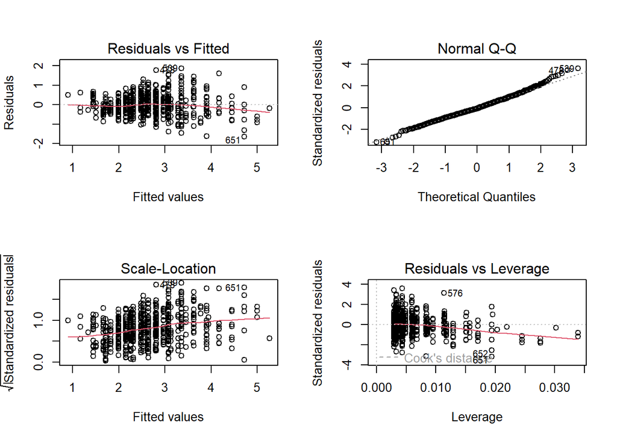

```r
# slike ostankov
par(mfrow = c(2, 2))
plot(model)
```

```r
# Cel izpis za model
summary(model)
```

```
##
## Call:
## lm(formula = FEV ~ Gender * Age, data = data)
##
## Residuals:
##      Min       1Q   Median       3Q      Max
## -1.64072 -0.34337 -0.04934  0.33206  1.86867
##
## Coefficients:
##                  Estimate Std. Error t value Pr(>|t|)
## (Intercept)      0.849467   0.102199   8.312 5.51e-16 ***
## GenderMoški     -0.775867   0.142745  -5.435 7.74e-08 ***
## Age              0.162729   0.009952  16.351  < 2e-16 ***
## GenderMoški:Age  0.110749   0.013786   8.033 4.47e-15 ***
## ---
## Signif. codes:  0 '***' 0.001 '**' 0.01 '*' 0.05 '.' 0.1 ' ' 1
##
## Residual standard error: 0.5196 on 650 degrees of freedom
## Multiple R-squared:  0.6425, Adjusted R-squared:  0.6408
## F-statistic: 389.4 on 3 and 650 DF,  p-value: < 2.2e-16
```

```r
names(summary(model)) # za dodatne ali posamezne izpise
```

```
##  [1] "call"          "terms"         "residuals"     "coefficients"
##  [5] "aliased"       "sigma"         "df"            "r.squared"
##  [9] "adj.r.squared" "fstatistic"    "cov.unscaled"
```

```r
# SSmodel in SSresidual
anova(model)
```

```
## Analysis of Variance Table
##
## Response: FEV
##             Df  Sum Sq Mean Sq  F value    Pr(>F)
## Gender       1  21.324  21.324   78.974 < 2.2e-16 ***
## Age          1 276.661 276.661 1024.615 < 2.2e-16 ***
## Gender:Age   1  17.426  17.426   64.535 4.467e-15 ***
## Residuals  650 175.509   0.270
## ---
## Signif. codes:  0 '***' 0.001 '**' 0.01 '*' 0.05 '.' 0.1 ' ' 1
```

```r
# Intervala zaupanja za parametra modela
confint(model) # Interpretacija: Če se napovedna_spr poveča za 1 (enota), pri 95 % zaupanju pričakujemo, da se bo odzivna_spr povečala na intervalu spodnja_meja (enota) do zgornja_meja (enota). → lahko pri interpretaciji tudi množiš vse z 10 ali 100
```

```
##                      2.5 %     97.5 %
## (Intercept)      0.6487862  1.0501481
## GenderMoški     -1.0561645 -0.4955686
## Age              0.1431865  0.1822713
## GenderMoški:Age  0.0836782  0.1378193
```

```r
# F-test za dva gnezdena modela:
anova(m1, model) #prvi je gnezden (to pomeni da ima manj regresorjev npr.: nima interakcije)
```

```
## Analysis of Variance Table
##
## Model 1: FEV ~ Gender + Age
## Model 2: FEV ~ Gender * Age
##   Res.Df    RSS Df Sum of Sq      F    Pr(>F)
## 1    651 192.94
## 2    650 175.51  1    17.425 64.535 4.467e-15 ***
## ---
## Signif. codes:  0 '***' 0.001 '**' 0.01 '*' 0.05 '.' 0.1 ' ' 1
```

```r
# R2 in ocene parametrov s pripadajočimi 95 % parcialnimi IZ
summary(model)$r.squared
```

```
## [1] 0.6424886
```

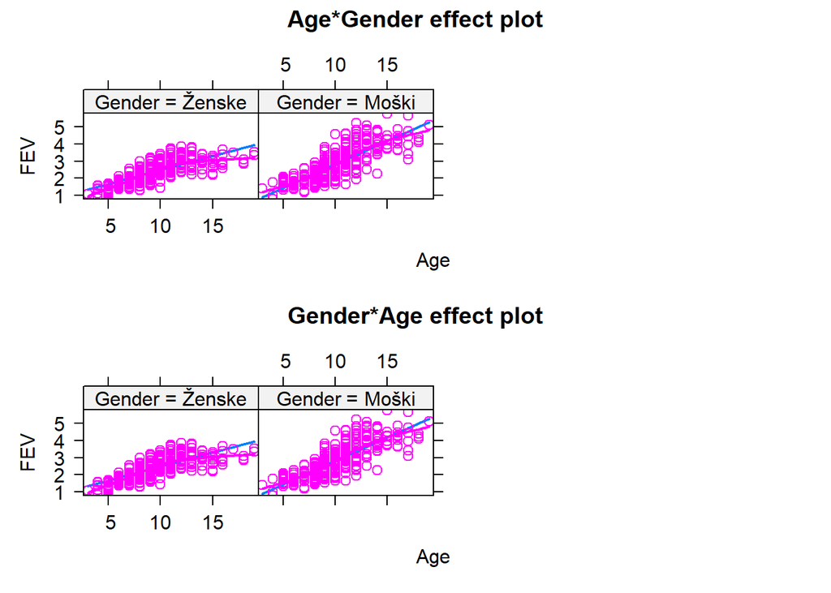

```r
#########################  INTERAKCIJE ##############################

par(mfrow = c(1,1))


# Indentifikacija interakcije med dvema številskima napovednima spr
graf1 = plot(Effect(c("Age", "Gender"), model, partial.residuals = TRUE),
             ci.style = "none", lattice = list(layout = c(4, 1)))
graf2 = plot(Effect(c("Gender", "Age"), model, partial.residuals = TRUE),
             ci.style = "none", lattice = list(layout = c(4, 1)))
grid.arrange(graf1, graf2) # razlaga spodaj
```

```r
# Rezultati sekvenčnih F-testov
anova(model) # Razlaga: P04, stran 24
```

```
## Analysis of Variance Table
##
## Response: FEV
##             Df  Sum Sq Mean Sq  F value    Pr(>F)
## Gender       1  21.324  21.324   78.974 < 2.2e-16 ***
## Age          1 276.661 276.661 1024.615 < 2.2e-16 ***
## Gender:Age   1  17.426  17.426   64.535 4.467e-15 ***
## Residuals  650 175.509   0.270
## ---
## Signif. codes:  0 '***' 0.001 '**' 0.01 '*' 0.05 '.' 0.1 ' ' 1
```

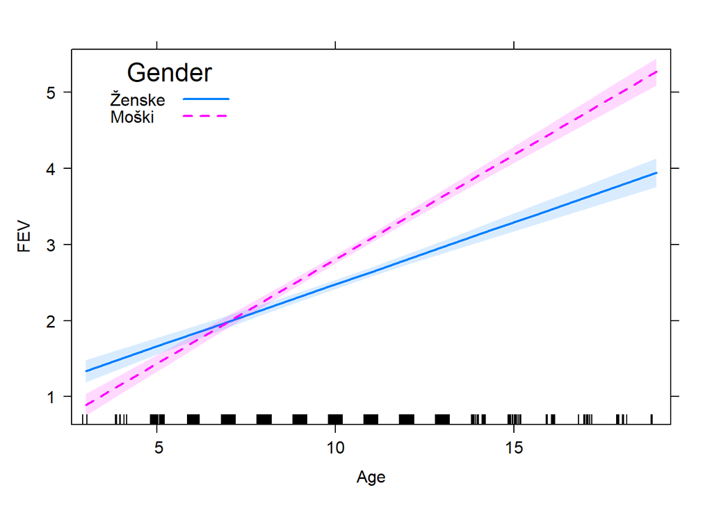

```r
# Interakcija med opisno in številsko napovedno spr
# Ta plot je bil narejen za vzporedni premici:
plot(Effect(c("Age", "Gender"), model), # lahko isti graf narediš brez/z interakcijo
     multiline = TRUE, ci.style = "bands",
     key.args = list(x = 0.05, y = 0.8, corner = c(0, 0)),
     main = "", lty = c(1:2))
```

# Interpretacije parametrov

## Osnovna linarna regresija brez interakcij

- Intercept: Pričakovana vrednost odzivne_spr pri napovedni_spr 0, je beta0.
- Beta1: Ko se napovedna_spr poveča za 1, se odzivna_spr poveča za beta1.

## Linerna regresija z 2 regresorjema brez interakcij

- Beta2: Torej velja, če napovedno_spr2 povečamo za eno enoto in ostane izbrana vrednost napovedne_spr1 nespremenjena, se pričakovana vrednost 𝑦 poveča za beta2.

** Z drugimi besedami: pri poljubni vrednosti napovedne_spr1 velja: če se napovedna_spr2 poveča za eno enoto, se odzivna_spr2 v povprečju poveča za beta2, pripadajoč 95 % IZ je (*,*)

## Linearna regresija z opisno napovedno spr z 2 vrednostima

Grafi ostankov: Tu primerjamo varianci napovedne_spr v dveh skupinah.

Glede na summary(model)$coeff: * Intercept = beta0: povprečje odzivne_spr pri referenčni skupini (preko p-vrednosti poglej, če je statistično značilno različno od 0) * za drugo vrednost napovedne_spr (nereferenčna skupina): Nereferenčan skupina ima za _**preberi cifro v 2. vrstici izpisa** manjšo/večjo vrednost odzivne_spr kot referenčna skupina (pogledaš p-vrednost, če je razlika med povprečjema referenčne in nereferenčne skupine značilna).

## Linearna regresija z opisno napovedno spr z več kot dvema vrednostma

Glede na summary(model)$coeff: * Intercept: povprečje odzivne_spr za referenčno skupino A * beta1: razlika povprečja odzivne_spr v skupini B in povprečja odzivne_spr v skupini A * beta2: razlika povprečja odzivne_spr v skupini C in povprečja odzivne_spr v skupini A

Najprej preverimo anova(model), da vidimo, če se splača gledati povzetek modela (anova je preverila, ali se model, ki vključuje beta0 in beta1 značilno razlikuje od tistega, ki je vključeval le beta0).

## Linearna regresija z opisno in številsko napovedno spr.

→ 2 premici, 2 možnosti:

### vzporedni, če ne vključimo interakcij:

- beta0: povprečna vrednost odzivne_spr pri referenčni skupini opisne_napovdne_spr in ko je številska_napovedna_spr enaka 0
- beta1: razlika povprečja odzivne_spr za referenčno in nereferenčno skupino opisne_napovedna_spr pri vseh vrednostih številske_napovedne_spr [min,max] → Referenčna skupina ima pri vseh analiziranih vrednostih številske_napovedne_spr za beta1 večjo/manjšo vrednost povprečne odzivne_spr kot nereferenčna skupina opisne_napovedne_spr. Pripadajoči IZ je: glej confint(model).
- beta2: naklon vzporednih premic → Če se številska_napovedna_spr poveča za 1 (ali množi z 10), se ob upoštevanju opisne_napovedne_spr odzivna_spr v povprečju poveča za beta2. Pripadajoči IZ je: glej confint(model).

### se sekata (drugačna naklona, drugačni začetni vrednosti), če vključimo interakcije:

- beta0: povprečna vrednost odzivne_spr pri referenčni skupini opisne_napovedne_spr in ko je številska_napovedna_spr enaka 0
- beta1: razlika povprečja odzivne_spr za referenčno in nereferenčno skupino opisne_napovedne_spr, ko je številska_napovedna_spr enaka 0
- beta2: naklon premice za referenčno skupino opisne_napovedne_spr
- beta3: razlika naklonov premic za referenčno skupino opisne_napovedne_spr in nereferenčno skupino

## Interakcija dveh številskih spremenljivk

Pri različnih vrednosti napovedne_spr1 je vpliv napovedne_spr2 na odzivno_spr različen, interakcija napovedna_spr1:napovedna_spr2 je negativna/pozitivna in statistično značilna/neznačilna (𝑝 = _). Glej: summary(model)$coeff.

Povedano drugače: Če x2 povečamo za eno enoto in ostane x1 nespremenjen, se pričakovana vrednost y poveča za beta2 + beta3*x1. → sprememba je pri različnih vrednostih x1 različna

## Interakcija številske in opisne napovedne spr

Grej zgoraj “se sekata (drugačna naklona, drugačni začetni vrednosti), če vključimo interakcije”.

# Povprečna in posamična napoved

```r
#vrednosti = data.frame(napovedna_spr1 = cifra, napovedna_spr2 = cifra)
#povp.napoved = predict(m1, vrednosti, interval = "confidence")
#pos.napoved = predict(m1, vrednosti, interval = "prediction")
#print(data.frame(cbind(vrednosti, povp.napoved, pos.napoved)))
```

# Gnezdeni model

anova(mod1,mod2)

- pri majhni p-vrednosti: 𝐹-test za primerjavo dveh gnezdenih modelov (mod1 in mod2) pokaže, da mod2 pojasni statistično pomemben del variabilnosti odzivne_spr. Modela mod1 in mod2 nista ekvivalentna (𝑝 = _), boljši je kompleksnejši mod2.

Prisotnost interakcije lahko preverimo tudi na podlagi $F$-testa za primerjavo gnezdenih modelov, ki testira domnevo, da sta modela ekvivalentna.

# Sekvenčni F-test

anova(model)

Poglej katere interkaicje so statistično značilne. Ali je interakcija v modelu potrebna ali ne lahko preverimo z $F$-testom. Z ukazom `anova(model)` izvedemo sekvenčni $F$-test, ki testira vpliv posamezne spremenljivke ob upoštevanju predhodnjih spremenljivk v modelu.

# Teoretična vprašanja

- Na kaj vpliva heteroskedastičnost? Vpliva na stand napake ocen parametorv - lahko so podcenjene ali precenjene (ponavadi podcenjene). Variabilnost bo napačno ocenjena - manjše SE - testno statistiko delimo s SE, torej bo t stat večja - p vrednost bo manjša kot v resnici - prevečkrat bomo zavrnili H0. Inferenca je problem, ne ocene.
- Predpostavke linearnega modela in kako odpravimo predpostavke (4. sklop)
- Kako heterskedastičnost vpliva na inferenco modela? Leva grafikona v prvi in drugi vrstici kažeta nekonstantno varianco. Varianca ostankov narašča z napovedanimi vrednostmi (zgornja leva sličica), slika ostankov je podobna klinu: variabilnost ostankov narašča od leve proti desni. Prisotnost nekonstantne variance še bolje pokaže gladilnik na levi spodnji sliki, kjer so na vodoravni osi napovedane vrednosti, na navpični osi pa koreni absolutnih vrednosti standardiziranih ostankov. V tem primeru so ocene parametrov sicer ustrezne (pri dokazu nepristranskosti cenilk smo pokazali, da ne potrebujemo predpostavke o konstantni varianci), njihove standardne napake pa ne, zato kakršnakoli inferenca za ta model ni utemeljena.